# Practica 2 - Diciembre 2021

Tipologia y Ciclo de Vida De Los Datos

Daniel Carretero San José - Ivan Tecles Gassó

# 1- Descripción del dataset y objetivos

Nuestra selección del dataset es: Red Wine Quality de Kaggle: * https://www.kaggle.com/uciml/red-wine-quality-cortez-et-al-2009

Tenemos dos conjuntos de datos que están relacionados con variantes tinto y blanco del vino portugués “Vinho Verde”.

Ambos datasets contienen 12 variables númericas:

- **fixed.acidity**: el nivel de la acidez fija.
- **volatile.acidity**: el nivel de la acidez volátil.
- **citric.acid**: el nivel del ácido cítrico.
- **residual.sugar**: el nivel del azúcar residual.
- **chlorides**: el nivel de los cloruros.
- **free.sulfur.dioxide**: el nivel del dióxido de azufre libre.
- **total.sulfur.dioxide**: el nivel del dióxido de azufre total.
- **density**: el nivel de la densidad.
- **pH**: el nivel del pH.
- **sulphates**: el nivel de los sulfatos.
- **alcohol**: el nivel del alcohol.
- **quality**: la calidad (entre 0 y 9).

Basicamente nos planteamos dos preguntas a resolver en la práctica planteada con este dataset: 1) ¿Existen diferencias de calidad entre el vino blanco y el vino tinto? 2) ¿Se puede predecir la calidad del vino a partir de las variables explicativas sin tener en cuenta el tipo de vino (tinto o blanco)?

# 2- Integración y selección de los datos de interés

Nuestra propuesta pasa por integrar ambos datasets en uno nuevo `dt_winequality` que contenga una nueva variable para determinar si el vino es tinto o blanco.

Primero realizamos la carga del archivos de datos `winequality-red.csv` y añadimos una nueva variable `type` con valor `red`.

```r
dt_red_wines<-read.csv("../datasets/winequality-red.csv", header=T, sep=";")
type<-"red"
dt_red_wines<-cbind(type, dt_red_wines)
```

A continuación realizamos la carga del archivos de datos `winequality-white.csv` y añadimos también la variable `type` esta vez con valor `white`.

```r
dt_white_wines<-read.csv("../datasets/winequality-white.csv", header=T, sep=";")
type<-"white"
dt_white_wines<-cbind(type, dt_white_wines)
```

Con las funciones `dim()` y `str()` comparamos las dimensiones de los conjuntos de datos y sus estructuras antes de realizar la integración de ambos datasets.

```r
dim(dt_red_wines)
```

```
## [1] 1599   13
```

```r
str(dt_red_wines)
```

```
## 'data.frame':    1599 obs. of  13 variables:
##  $ type                : chr  "red" "red" "red" "red" ...
##  $ fixed.acidity       : num  7.4 7.8 7.8 11.2 7.4 7.4 7.9 7.3 7.8 7.5 ...
##  $ volatile.acidity    : num  0.7 0.88 0.76 0.28 0.7 0.66 0.6 0.65 0.58 0.5 ...
##  $ citric.acid         : num  0 0 0.04 0.56 0 0 0.06 0 0.02 0.36 ...
##  $ residual.sugar      : num  1.9 2.6 2.3 1.9 1.9 1.8 1.6 1.2 2 6.1 ...
##  $ chlorides           : num  0.076 0.098 0.092 0.075 0.076 0.075 0.069 0.065 0.073 0.071 ...
##  $ free.sulfur.dioxide : num  11 25 15 17 11 13 15 15 9 17 ...
##  $ total.sulfur.dioxide: num  34 67 54 60 34 40 59 21 18 102 ...
##  $ density             : num  0.998 0.997 0.997 0.998 0.998 ...
##  $ pH                  : num  3.51 3.2 3.26 3.16 3.51 3.51 3.3 3.39 3.36 3.35 ...
##  $ sulphates           : num  0.56 0.68 0.65 0.58 0.56 0.56 0.46 0.47 0.57 0.8 ...
##  $ alcohol             : num  9.4 9.8 9.8 9.8 9.4 9.4 9.4 10 9.5 10.5 ...
##  $ quality             : int  5 5 5 6 5 5 5 7 7 5 ...
```

```r
dim(dt_white_wines)
```

```
## [1] 4898   13
```

```r
str(dt_white_wines)
```

```
## 'data.frame':    4898 obs. of  13 variables:
##  $ type                : chr  "white" "white" "white" "white" ...
##  $ fixed.acidity       : num  7 6.3 8.1 7.2 7.2 8.1 6.2 7 6.3 8.1 ...
##  $ volatile.acidity    : num  0.27 0.3 0.28 0.23 0.23 0.28 0.32 0.27 0.3 0.22 ...
##  $ citric.acid         : num  0.36 0.34 0.4 0.32 0.32 0.4 0.16 0.36 0.34 0.43 ...
##  $ residual.sugar      : num  20.7 1.6 6.9 8.5 8.5 6.9 7 20.7 1.6 1.5 ...
##  $ chlorides           : num  0.045 0.049 0.05 0.058 0.058 0.05 0.045 0.045 0.049 0.044 ...
##  $ free.sulfur.dioxide : num  45 14 30 47 47 30 30 45 14 28 ...
##  $ total.sulfur.dioxide: num  170 132 97 186 186 97 136 170 132 129 ...
##  $ density             : num  1.001 0.994 0.995 0.996 0.996 ...
##  $ pH                  : num  3 3.3 3.26 3.19 3.19 3.26 3.18 3 3.3 3.22 ...
##  $ sulphates           : num  0.45 0.49 0.44 0.4 0.4 0.44 0.47 0.45 0.49 0.45 ...
##  $ alcohol             : num  8.8 9.5 10.1 9.9 9.9 10.1 9.6 8.8 9.5 11 ...
##  $ quality             : int  6 6 6 6 6 6 6 6 6 6 ...
```

```r
dt_winequality<-rbind(dt_red_wines, dt_white_wines)
dim(dt_winequality)
```

```
## [1] 6497   13
```

Los resultados muestran que los datos (6497 observaciones y 13 variables) se han integrado correctamente.

# 3- Limpieza de datos

## 3.1 - Valores perdidos

La función `plot_intro(dt_winequality)` describe la información básica para los datos de entrada.

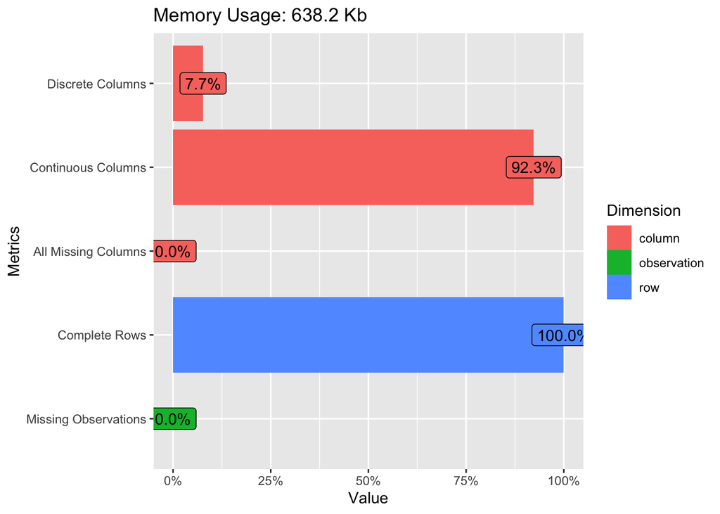

```r
plot_intro(dt_winequality)
```

Observamos que no hay valores perdidos.

## 3.2 - Identificación y tratamiento de valores extremos

Diagrama de caja para la variable `fixed.acidity`.

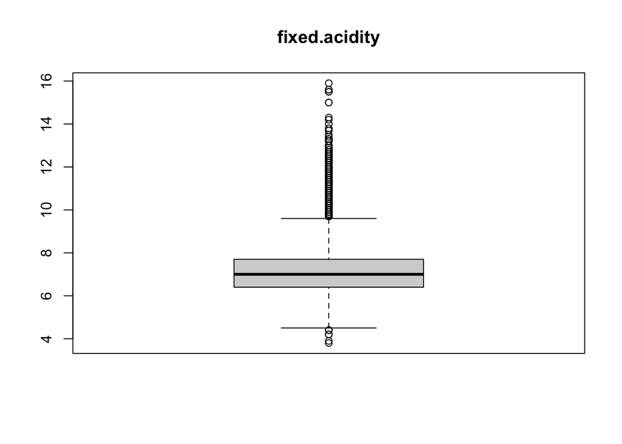

```r
boxplot(dt_winequality$fixed.acidity, main="fixed.acidity", names=c("red & white"))
```

Utilizamos la función `boxplot.stats()` con coeficiente 3 para calcular el lower y upper whiskers.

```r
box_plot_results<-boxplot.stats(dt_winequality$fixed.acidity, coef=3)
boxplot.stats(dt_winequality$fixed.acidity, coef=3)
```

```
## $stats
## [1]  3.8  6.4  7.0  7.7 11.6
##
## $n
## [1] 6497
##
## $conf
## [1] 6.974517 7.025483
##
## $out
##  [1] 12.8 12.8 12.0 15.0 15.0 12.5 11.8 12.0 13.3 13.4 11.9 12.4 12.5 12.2 11.9
## [16] 13.8 13.5 11.9 12.6 11.9 12.5 12.8 12.8 14.0 13.7 13.7 12.7 12.0 12.2 12.0
## [31] 12.5 11.9 12.8 11.9 12.3 12.3 12.6 11.9 15.6 12.5 11.9 11.9 13.0 12.5 13.3
## [46] 12.4 12.5 11.9 11.9 12.9 14.3 12.4 15.5 15.5 15.6 13.0 12.7 13.0 12.7 12.3
## [61] 12.3 12.3 11.7 12.0 11.8 12.4 11.9 12.7 13.2 13.2 13.2 15.9 12.0 12.1 13.3
## [76] 11.8 12.9 12.6 11.7 12.0 12.2 12.2 12.6 11.7 14.2 11.8
```

```r
lower_whisker<-box_plot_results$stats[1]
upper_whisker<-box_plot_results$stats[5]
```

Imputamos los valores lower y upper whiskers si nuestros valores extremos son inferiores o superiores respectivamente.

```r
dt_winequality$fixed.acidity[which(dt_winequality$fixed.acidity < lower_whisker)]<-lower_whisker
dt_winequality$fixed.acidity[which(dt_winequality$fixed.acidity > upper_whisker)]<-upper_whisker
```

Se aplica este mismo tratamiento al resto de variables explicativas.

Diagrama de caja para la variable `quality`.

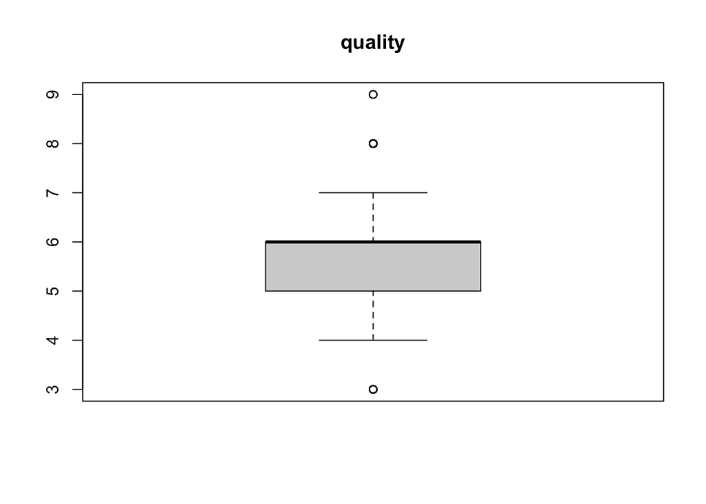

```r
boxplot(dt_winequality$quality, main="quality", names=c("red & white"))
```

Con la variable `quality` será la única que aceptamos los valores extremos como válidos, pues nos da una mayor información acerca de la calidad de los vinos, por tanto no realizamos ningún tratamiento sobre ella.

# 4- Análisis de datos y representación de resultados

## 4.1 - Selección del grupo de datos que se quiere analizar

### 4.1.1 - Correlación de variables

Se mira la correlación entre variables explicativas para ver si es descartable alguna de ellas.

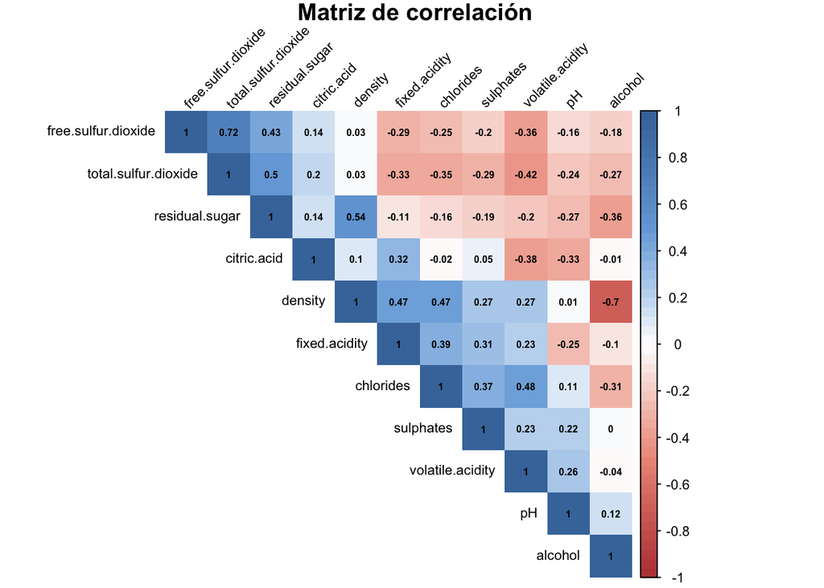

```r
dt_winequality.corr<-dt_winequality %>% dplyr::select(!c(quality, type))
dt_winequality.mat.corr<-cor(dt_winequality.corr, method="pearson", use="pairwise.complete.obs")
col<-colorRampPalette(c("#BB4444", "#EE9988", "#FFFFFF", "#77AADD", "#4477AA"))


corrplot(dt_winequality.mat.corr, type="upper", method="shade", shade.col=NA, tl.col="black", tl.srt=45, col=col(50), addCoef.col="black", order="AOE", mar=c(0.0001, 1, 1, 1), number.cex=0.5, cl.cex=0.7, tl.cex=0.7, title=" Matriz de correlación")
```

Las correlaciones mas altas son:

- density con alcohol (-0.69)
- free.sulfur.dioxide con total.sulfur.dioxide (0.72)

Aún siendo altas ambas correlaciones, se decide mantener estas variables en el modelado. En caso de haber habido un conjunto mayor de variables explicativas, estas variables correlacionadas hubiesen sido las primeras candidatas a eliminarse del modelo, pero el no tener unos valores mas próximos a 1 y el hecho de no tener excesivas variables explicativas se ha optado por mantenerlas.

Por último comentar que se va a generar una variable dicotimica a partir de la variable de calidad. Esta variable “quality_class” permitirá clasificar el vino y hacer algoritmos predictivos sobre una variable de respuesta categorica.

```r
dt_winequality<-mutate(dt_winequality, quality_class=ifelse(quality >=7 , "good", "not good"))
dt_winequality$quality_class<-as.factor(dt_winequality$quality_class)
```

### 4.1.2 - Reducción de la dimensionalidad (PCA)

Se aplica el algoritmo PCA para obtener las componentes principales y plantear una reducción de la dimensionalidad del problema.

```r
pca<-prcomp(dt_winequality.corr, scale=TRUE)
```

El aporte de cada una de las variables a las componentes principales es el siguiente:

```r
pca$rotation
```

```
##                              PC1         PC2         PC3          PC4
## fixed.acidity        -0.26523000  0.30053597 -0.45943887  0.104904828
## volatile.acidity     -0.39061212  0.07646597  0.28469500  0.228249727
## citric.acid           0.14311600  0.18421933 -0.59107861 -0.294449825
## residual.sugar        0.30841558  0.36500240  0.15688542  0.108821769
## chlorides            -0.35929072  0.29569217  0.05442002 -0.049115122
## free.sulfur.dioxide   0.41267470  0.12949774  0.15021229 -0.304368509
## total.sulfur.dioxide  0.46276128  0.14551331  0.12371957 -0.170191867
## density              -0.11061421  0.57711992  0.14423628 -0.008820602
## pH                   -0.20943585 -0.16917526  0.45282536 -0.488968006
## sulphates            -0.29879184  0.13336062 -0.08100097 -0.679021477
## alcohol              -0.05058835 -0.48147399 -0.24623130 -0.118738055
##                              PC5         PC6         PC7         PC8
## fixed.acidity        -0.03699145 -0.15543607 -0.15372312  0.58638283
## volatile.acidity      0.11753236 -0.48442823 -0.38297808  0.01153911
## citric.acid          -0.02519570  0.26398778 -0.43260681 -0.22536076
## residual.sugar       -0.56022085 -0.22427504 -0.07802930 -0.38338515
## chlorides             0.50629899  0.12012735 -0.15392173 -0.53770027
## free.sulfur.dioxide   0.38629794 -0.32085401 -0.20719713  0.18027215
## total.sulfur.dioxide  0.24216237 -0.14933079 -0.07582922  0.14947429
## density              -0.28547911  0.04618588 -0.06935439  0.11069707
## pH                   -0.25437140  0.36864675 -0.42093792  0.22573139
## sulphates            -0.08876161 -0.34836164  0.51056980 -0.07535225
## alcohol              -0.22813683 -0.47128878 -0.34843487 -0.21307684
##                              PC9         PC10          PC11
## fixed.acidity         0.26695407 -0.215771220 -0.3262147059
## volatile.acidity     -0.51874867  0.195998001 -0.0749707802
## citric.acid          -0.38613039  0.228362098 -0.0000585341
## residual.sugar        0.13660394 -0.039191701 -0.4447266638
## chlorides             0.33340717 -0.277336632 -0.0802733211
## free.sulfur.dioxide   0.38015729  0.474973917  0.0020318274
## total.sulfur.dioxide -0.35098102 -0.696862576  0.0506558192
## density               0.08695531  0.005905255  0.7249301713
## pH                    0.07169909 -0.098377029 -0.1995204282
## sulphates            -0.15172251  0.023693406 -0.0783072568
## alcohol               0.27800853 -0.250868010  0.3312150531
```

Las desviaciones standard de cada una de las componentes principales puede ser obtenida del siguiente modo:

```r
pca$sdev
```

```
##  [1] 1.7791160 1.5967648 1.2478353 0.9758430 0.8036676 0.7780564 0.7164030
##  [8] 0.6433271 0.5816124 0.4790486 0.1720718
```

A partir de las desviaciones standard se obtienen las varianzas y se divide por la suma de varianzas para obtener la proporcion de varianza que aportan cada una de las componentes principales.

```r
prop_varianza<-pca$sdev^2/sum(pca$sdev^2)
prop_varianza
```

```
##  [1] 0.287750351 0.231787073 0.141553912 0.086569968 0.058716513 0.055033800
##  [7] 0.046657570 0.037624527 0.030752087 0.020862501 0.002691699
```

Se representa de manera gráfica el aporte de las diez componentes principales a la varianza:

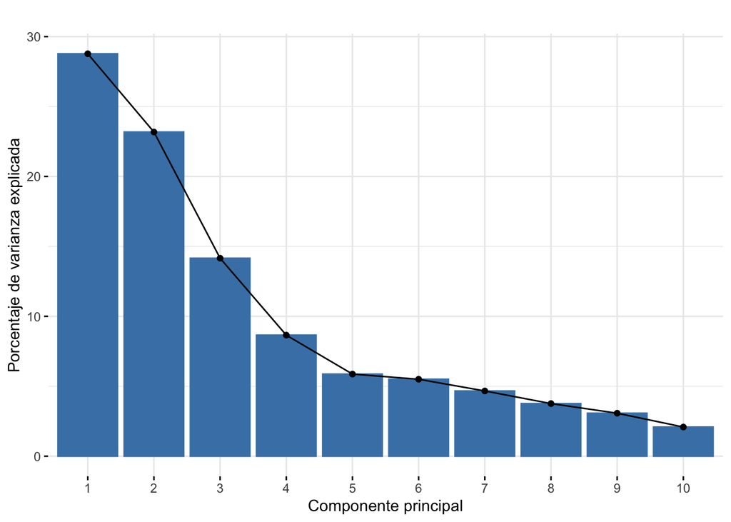

```r
fviz_eig(pca, xlab="Componente principal", ylab="Porcentaje de varianza explicada", main="", ncp=10)
```

También se representa de manera gráfica la descomposición de cada una de las variables predictoras en las dos componentes principales:

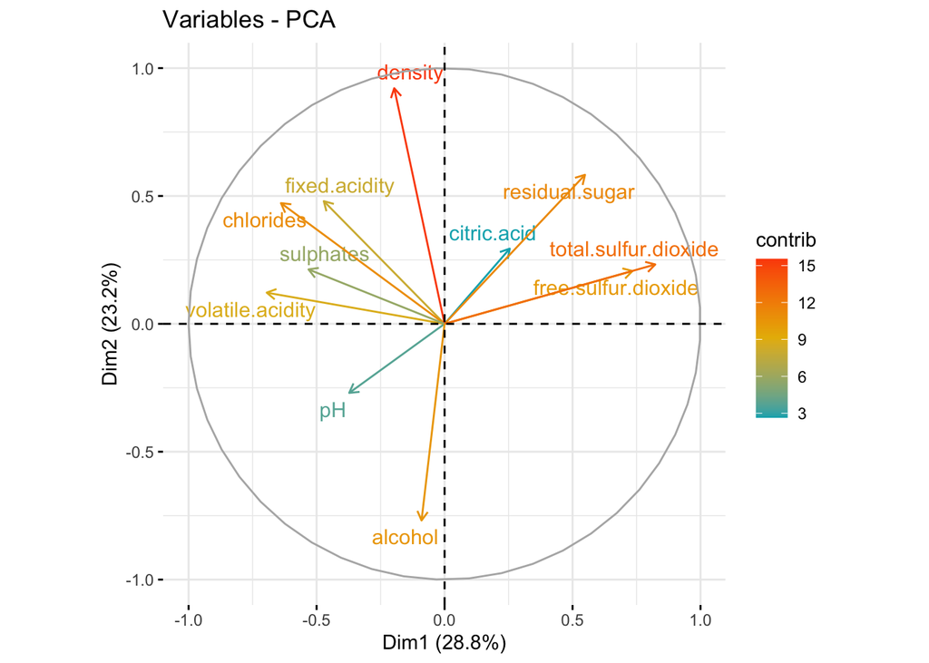

```r
fviz_pca_var(pca,
             col.var="contrib", # Color by contributions to the PC
             gradient.cols=c("#00AFBB", "#E7B800", "#FC4E07"),
             repel=TRUE     # Avoid text overlapping
             )
```

Se calcula la proporción de varianza acumulada de las componentes principales:

```r
prop_varianza_acum<-cumsum(prop_varianza)
prop_varianza_acum
```

```
##  [1] 0.2877504 0.5195374 0.6610913 0.7476613 0.8063778 0.8614116 0.9080692
##  [8] 0.9456937 0.9764458 0.9973083 1.0000000
```

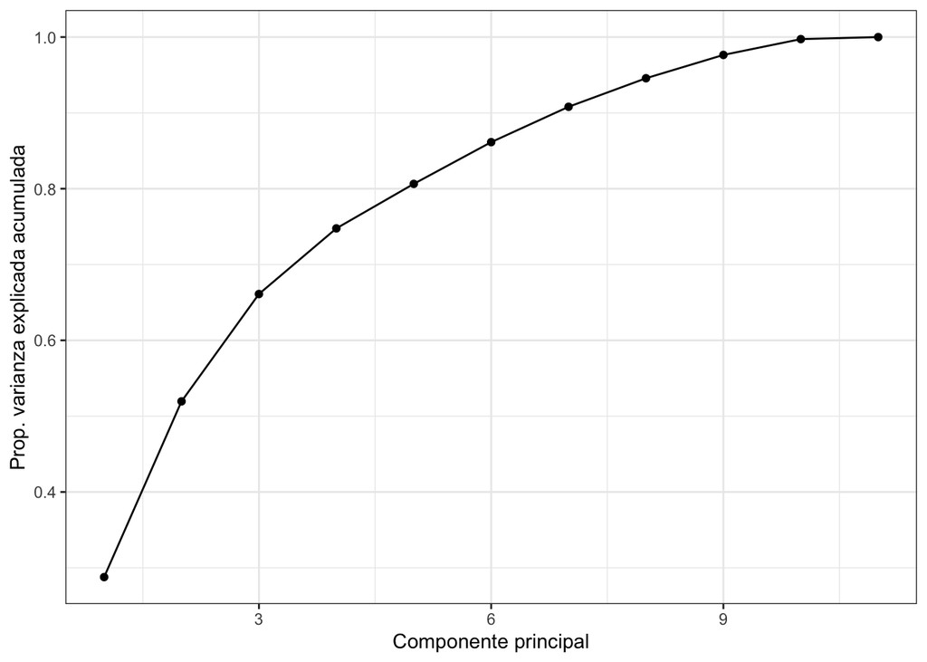

```r
ggplot(data=data.frame(prop_varianza_acum, pc=1:11),
       aes(x=pc, y=prop_varianza_acum, group=1)) +
       geom_point() +
       geom_line() +
       theme_bw() +
       labs(x="Componente principal",
            y="Prop. varianza explicada acumulada")
```

## 4.2 - Comprobación de la normalidad y homogeneidad de la varianza

Se va a trabajar para el contraste de hipotesis con las medias muestrales, con lo cual al ser una muestra mayor de 30 elementos puede aplicarse el teorema del limite central bajo el cual se supone que dichas medias muestrales siguen una distribución normal.

```r
var.test(dt_red_wines$quality, dt_white_wines$quality)
```

```
##
##  F test to compare two variances
##
## data:  dt_red_wines$quality and dt_white_wines$quality
## F = 0.83147, num df = 1598, denom df = 4897, p-value = 8.561e-06
## alternative hypothesis: true ratio of variances is not equal to 1
## 95 percent confidence interval:
##  0.7682689 0.9013500
## sample estimates:
## ratio of variances
##          0.8314702
```

## 4.3 - Pruebas estadísticas

### 4.3.1 - Contraste de hipotesis

Se realiza un contraste de hipotesis sobre de las medias de calidad de vino blanco y tinto para ver si son iguales o diferentes.

- H0: $\mu_{red}=\mu_{white}$
- H1: $\mu_{red} \neq \mu_{white}$

```r
t.test(dt_red_wines$quality, dt_white_wines$quality, alternative="two.sided", var.equal=TRUE)
```

```
##
##  Two Sample t-test
##
## data:  dt_red_wines$quality and dt_white_wines$quality
## t = -9.6856, df = 6495, p-value < 2.2e-16
## alternative hypothesis: true difference in means is not equal to 0
## 95 percent confidence interval:
##  -0.2908436 -0.1929301
## sample estimates:
## mean of x mean of y
##  5.636023  5.877909
```

Se puede observar que realmente hay una diferencia en las medias de calidad entre tipos de vino al ser el p-value mucho menor que el valor de significancia de 0.05 y ser por tanto rechazable la hipotesis nula. Las medias de calidad del vino tinto y del blanco son significativamente diferentes desde un punto de vista estadístico.

### 4.3.2 - Modelado y evaluación de algoritmos Predictivos

#### 4.3.2.1 - Partición en conjuntos de entrenamiento y test

```r
set.seed(3456)
trainIndex<-createDataPartition(dt_winequality$quality_class, p=.7,
                                  list=FALSE,
                                  times=1)

dt_winequality.data.train<-dt_winequality[trainIndex, ]%>%dplyr::select(-c(quality))
dt_winequality.data.test<-dt_winequality[-trainIndex, ]%>%dplyr::select(-c(quality))
```

#### 4.3.2.2 - Tuning básico de parametros configurando cross-validation

```r
fitControl<-trainControl(## 10-fold CV
                         method="repeatedcv",
                         number=10,
                         ## repeated ten times
                         repeats=10)
```

#### 4.3.2.3. - Obtención de modelos

#### 4.3.2.3.1 - CART

```r
modelRPART<-train(quality_class ~ ., data=dt_winequality.data.train, method="rpart", trControl=fitControl)
modelRPART
```

```
## CART
##
## 4548 samples
##   12 predictor
##    2 classes: 'good', 'not good'
##
## No pre-processing
## Resampling: Cross-Validated (10 fold, repeated 10 times)
## Summary of sample sizes: 4092, 4092, 4093, 4094, 4093, 4094, ...
## Resampling results across tuning parameters:
##
##   cp          Accuracy   Kappa
##   0.01901566  0.8164480  0.2651332
##   0.03020134  0.8066181  0.1629971
##   0.03094705  0.8058488  0.1438621
##
## Accuracy was used to select the optimal model using the largest value.
## The final value used for the model was cp = 0.01901566.
```

#### 4.3.2.3.2 - KNN

```r
modelKNN<-train(quality_class ~ ., data=dt_winequality.data.train, method="knn", trControl=fitControl)
modelKNN
```

```
## k-Nearest Neighbors
##
## 4548 samples
##   12 predictor
##    2 classes: 'good', 'not good'
##
## No pre-processing
## Resampling: Cross-Validated (10 fold, repeated 10 times)
## Summary of sample sizes: 4094, 4093, 4094, 4094, 4093, 4093, ...
## Resampling results across tuning parameters:
##
##   k  Accuracy   Kappa
##   5  0.7909876  0.2475163
##   7  0.7959339  0.2242788
##   9  0.7998260  0.2099884
##
## Accuracy was used to select the optimal model using the largest value.
## The final value used for the model was k = 9.
```

#### 4.3.2.3.3 - Generalized Linear Model

```r
modelGLM<-train(quality_class ~ ., data=dt_winequality.data.train, method="glm", trControl=fitControl)
modelGLM
```

```
## Generalized Linear Model
##
## 4548 samples
##   12 predictor
##    2 classes: 'good', 'not good'
##
## No pre-processing
## Resampling: Cross-Validated (10 fold, repeated 10 times)
## Summary of sample sizes: 4093, 4094, 4093, 4093, 4094, 4092, ...
## Resampling results:
##
##   Accuracy   Kappa
##   0.8197459  0.2961414
```

#### 4.3.2.3.4 - Comparativa de modelos

Para comparar los diferentes modelos, al habarse obtenido todos a partir del paquete Caret se puede usar la función resamples.

```r
results<-resamples(list(RPART=modelRPART, KNN=modelKNN, GLM=modelGLM))
# summarize the distributions
summary(results)
```

```
##
## Call:
## summary.resamples(object = results)
##
## Models: RPART, KNN, GLM
## Number of resamples: 100
##
## Accuracy
##            Min.   1st Qu.    Median      Mean   3rd Qu.      Max. NA's
## RPART 0.7934066 0.8080319 0.8175824 0.8164480 0.8241758 0.8439560    0
## KNN   0.7604396 0.7890110 0.7989025 0.7998260 0.8106768 0.8399123    0
## GLM   0.7872807 0.8134941 0.8208807 0.8197459 0.8263736 0.8502203    0
##
## Kappa
##             Min.   1st Qu.    Median      Mean   3rd Qu.      Max. NA's
## RPART 0.12991538 0.2397965 0.2670064 0.2651332 0.2942130 0.3884513    0
## KNN   0.05574777 0.1742830 0.2023208 0.2099884 0.2547751 0.3465773    0
## GLM   0.16164522 0.2671301 0.2929325 0.2961414 0.3245829 0.4216344    0
```

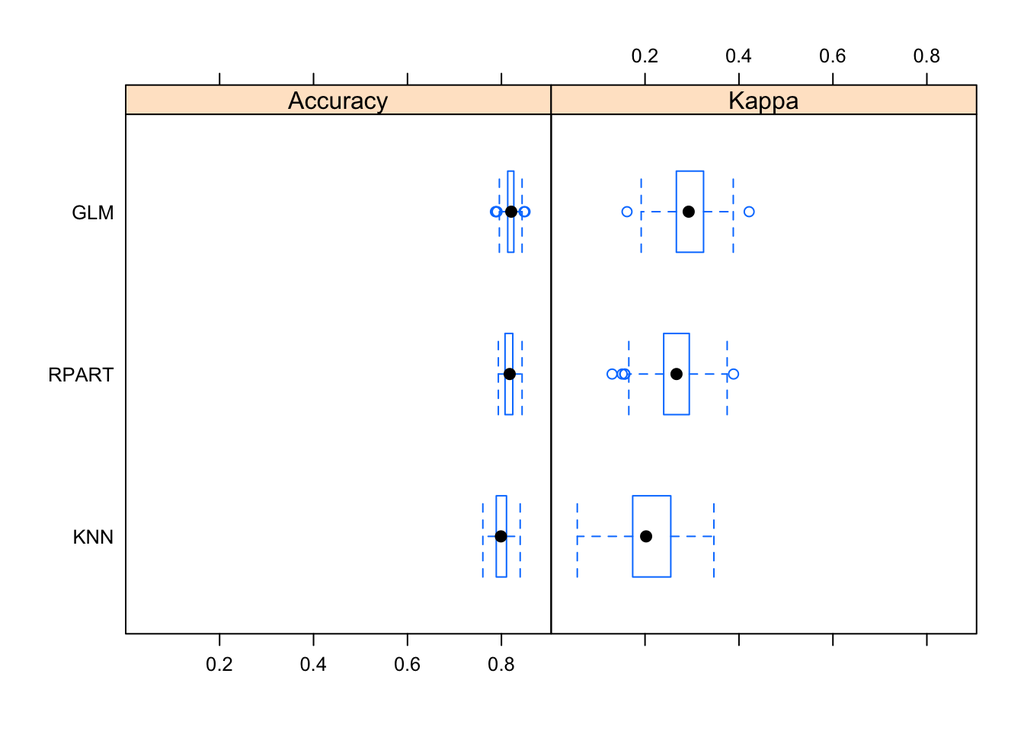

```r
# boxplots of results
bwplot(results)
```

Por lo que se puede observar el mejor modelo parece ser el GLM, aunque si se quisiera ver de una manera mas purista si las diferencias mostradas son estadisticamente significativas se debería hacer un test estadístico sobre las métricas obtenidas.

### 4.3.3 - Prediccion con algoritmo GLM seleccionado sobre el conjunto de test

```r
dt_winequality.data.test.X<-dt_winequality.data.test%>%dplyr::select(-c(quality_class))
dt_winequality.data.test.Y<-as.factor((dt_winequality.data.test%>%dplyr::select(c(quality_class)))$quality_class)
predicted_GLM<-predict(modelGLM, dt_winequality.data.test.X)
```

### 4.3.4 - Matriz confusión sobre el conjunto de test

```r
confusionMatrix(reference=dt_winequality.data.test.Y, data=predicted_GLM, mode='everything', positive='good')
```

```
## Confusion Matrix and Statistics
##
##           Reference
## Prediction good not good
##   good      123      109
##   not good  260     1457
##
##                Accuracy : 0.8107
##                  95% CI : (0.7926, 0.8278)
##     No Information Rate : 0.8035
##     P-Value [Acc > NIR] : 0.2215
##
##                   Kappa : 0.2956
##
##  Mcnemar's Test P-Value : 5.779e-15
##
##             Sensitivity : 0.32115
##             Specificity : 0.93040
##          Pos Pred Value : 0.53017
##          Neg Pred Value : 0.84857
##               Precision : 0.53017
##                  Recall : 0.32115
##                      F1 : 0.40000
##              Prevalence : 0.19651
##          Detection Rate : 0.06311
##    Detection Prevalence : 0.11904
##       Balanced Accuracy : 0.62577
##
##        'Positive' Class : good
##
```

### 4.3.5 - ROC y AUC

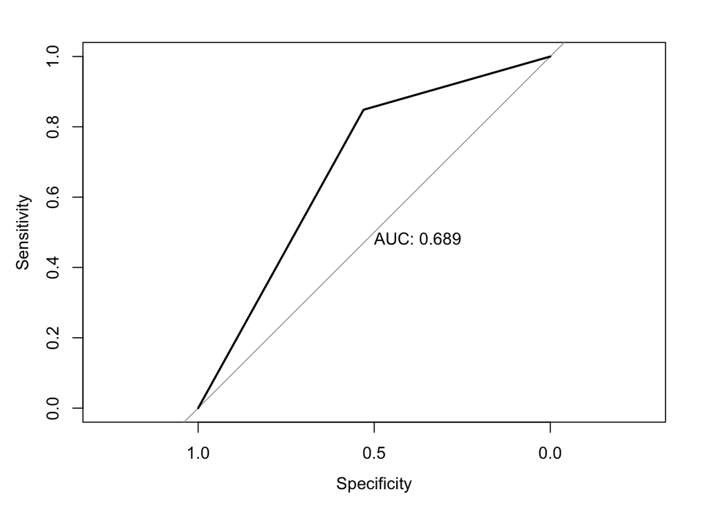

```r
plot.roc(as.numeric(predicted_GLM), as.numeric(dt_winequality.data.test.Y), print.auc=TRUE)
```

# 5- Conclusiones

Se ha mirado la reducción de la dimensionalidad del problema a partir del estudio de correlación de variables y de la aplicación de PCA.

Las correlaciones de variables aunque alta en un par de ellas no es excesivamente alta y debido al limitado número de variables se opta por manternerlas en la obtención del modelo.

Al principio de la práctica se plantearon dos objetivos:

1. Validar si la calidad del vino tinto y blanco son diferentes.
2. Obtener un modelo que sea capaz de clasificar la calidad del vino en una variable dicotómica good/not good.

Respecto del segundo objetivo se han probado diversos algoritmos ofrecidos por la libreria CARET. Tras comparar las metricas Accuracy y Kappa de los tres algoritmos probados (CART, KNN y GLM) mediante el uso de la función resamples se determina que el algoritmo GLM es el que mejor desempeño tiene.

# 6 - Código fuente

El código fuente puede ser consultado en nuestro repositorio [Github](https://github.com/dcarretero/UOC-TCVD-Practica_2)

# 7 - Vídeo

Por último compartimos un vídeo explicativo de la práctica: Vídeo Práctica 2 Daniel Carretero Ivan Tecles

# 8 - Recursos

Los siguientes recursos son de utilidad para la realización de la práctica:

- Calvo M., Subirats L., Pérez D. (2019). Introducción a la limpieza y análisis de los datos. Editorial UOC.
- Megan Squire (2015). Clean Data. Packt Publishing Ltd.
- Jiawei Han, Micheine Kamber, Jian Pei (2012). Data mining: concepts and techniques. Morgan Kaufmann.

| Contribuciones | Firma |
| --- | --- |
| Investigación | Daniel Carretero, Iván Tecles |
| Redacción de las respuestas | Daniel Carretero, Iván Tecles |
| Desarrollo del código | Daniel Carretero, Iván Tecles |